# Wallace Session 2025-10-09

Please find below the R code history from your *Wallace* v2.2.0 session.

You can reproduce your session results by running this R Markdown file in RStudio.

Each code block is called a “chunk”, and you can run them either one-by-one or all at once by choosing an option in the “Run” menu at the top-right corner of the “Source” pane in RStudio.

For more detailed information see http://rmarkdown.rstudio.com).

### Package installation

Wallace uses the following R packages that must be installed and loaded before starting.

```r
library(spocc)
library(spThin)
library(dismo)
library(sf)
library(ENMeval)
library(wallace)
```

The *Wallace* session code .Rmd file is composed of a chain of module functions that are internal to *Wallace*. Each of these functions corresponds to a single module that the user ran during the session. To see the internal code for these module functions, click on the links in the .Rmd file. Users are encouraged to write custom code in the .Rmd directly to modify their analysis, and even modify the module function code to further customize. To see the source code for any module function, just type its name into the R console and press Return.

```r
# example:
# just type the function name and press Return to see its source code
# paste this code into a new script to edit it
occs_queryDb
```

[output not shown]

[output cut: 173 more lines]

[output not shown]

Your analyses are below.

## Analysis for *Dichotomius agenor* (Da)

User CSV path with occurrence data. If the CSV file is not in the current workspace, change to the correct file path (e.g. “/Users/darwin/Documents/occs/”).

```r
# NOTE: provide the folder path of the .csv file
occs_path <- "C:/Users/usuario/Documents/Posgrado/Proyecto integrador/REPOSITORIO/beetle-habitat-prediction/datos_presencia_gbif/datos_1.csv"
occs_path <- file.path(occs_path)
# get a list of species occurrence data
userOccs_Da <- occs_userOccs(
  txtPath = occs_path,
  txtName = "datos_1.csv",
  txtSep = ",",
  txtDec = ".")
```

[output not shown]

```r
occs_Da <- userOccs_Da$Dichotomius_agenor$cleaned
```

### Obtain environmental data

Using WorldClim v2.1 (http://www.worldclim.org/) bioclimatic dataset at resolution of 0.5 arcmin.

```r
# Download environmental data
envs_Da <- envs_worldclim(
  bcRes = 0.5,
  bcSel = c('bio01', 'bio02', 'bio04', 'bio05', 'bio06', 'bio08', 'bio09', 'bio10', 'bio11', 'bio12', 'bio13', 'bio14', 'bio15', 'bio16', 'bio17', 'bio18', 'bio19'),
  mapCntr = c(-73.287, 8.839), # Mandatory for 30 arcsec resolution
  doBrick = FALSE)
```

```
## Retrieving WorldClim data...
```

```
## WorldClim bioclimatic variables bio01, bio02, bio04, bio05, bio06, bio08, bio09, bio10, bio11, bio12, bio13, bio14, bio15, bio16, bio17, bio18, bio19 at 0.5 arcmin resolution.
```

```r
occs_xy_Da <- occs_Da[c('longitude', 'latitude')]
occs_vals_Da <- as.data.frame(raster::extract(envs_Da, occs_xy_Da, cellnumbers = TRUE))
# Remove duplicated same cell values
occs_Da <- occs_Da[!duplicated(occs_vals_Da[, 1]), ]
occs_vals_Da <- occs_vals_Da[!duplicated(occs_vals_Da[, 1]), -1]
# remove occurrence records with NA environmental values
occs_Da <- occs_Da[!(rowSums(is.na(occs_vals_Da)) >= 1), ]
# also remove variable value rows with NA environmental values
occs_vals_Da <- na.omit(occs_vals_Da)
# add columns for env variable values for each occurrence record
occs_Da <- cbind(occs_Da, occs_vals_Da)
```

### Process Occurrence Data

Thinning the occurrences to 1 km

```r
# Thin occurrences
occs_Da <- poccs_thinOccs(
  occs = occs_Da,
  thinDist = 1)
```

```
## Spatially thinning for species...
```

```
## Total records thinned (1 km) to 123 localities
```

### Process environmental data

Sampling of 1000 background points and corresponding environmental data using a “point buffers” method with a 0.45 degree buffer.

```r
# Generate background extent
bgExt_Da <- penvs_bgExtent(
  occs = occs_Da,
  bgSel = "point buffers",
  bgBuf = 0.45)
```

```
## Study extent: buffered points.  Buffered by 0.45 degrees.
```

```r
# Mask environmental data to provided extent
bgMask_Da <- penvs_bgMask(
  occs = occs_Da,
  envs = envs_Da,
  bgExt = bgExt_Da)
```

```
## Masking rasters for species...
```

```
## Environmental data masked.
```

```r
# Sample background points from the provided area
bgSample_Da <- penvs_bgSample(
  occs = occs_Da,
  bgMask =  bgMask_Da,
  bgPtsNum = 1000)
```

```
## Generating background points...
```

```
## 1000 random background points sampled out of 237783 total points.
```

```r
# Extract values of environmental layers for each background point
bgEnvsVals_Da <- as.data.frame(raster::extract(bgMask_Da,  bgSample_Da))
##Add extracted values to background points table
bgEnvsVals_Da <- cbind(scientific_name = paste0("bg_", "Dichotomius agenor"), bgSample_Da,
                            occID = NA, year = NA, institution_code = NA, country = NA,
                            state_province = NA, locality = NA, elevation = NA,
                            record_type = NA, bgEnvsVals_Da)
```

### Partition occurrence data

Partition occurrences and background points for model training and validation using “spatial block”, a spatial partition method with an aggregation factor of 2.

```r
# R code to get partitioned data
groups_Da <- part_partitionOccs(
  occs = occs_Da ,
  bg =  bgSample_Da,
  method = "block",
  bgMask = bgMask_Da,
  aggFact = 2)
```

```
## Occurrences partitioned by block method.
```

### Build and Evaluate Niche Model

Generating a species distribution model using the maxnet algorithm as implemented in ENMeval V2.0 (with clamping = TRUE). For tuning using L, LQ feature classes and regularization multipliers in the 2, 2 range increasing by 2. Not using any categorical predictor variables.

```r
# Run maxent model for the selected species
model_Da <- model_maxent(
  occs = occs_Da,
  bg = bgEnvsVals_Da,
  user.grp = groups_Da,
  bgMsk = bgMask_Da,
  rms = c(2, 2),
  rmsStep =  2,
  fcs = c('L', 'LQ'),
  clampSel = TRUE,
  algMaxent = "maxnet",
  parallel = TRUE,
  numCores = 2)
```

```
## *** Running initial checks... ***
```

```
## * Clamping predictor variable rasters...
```

```
## * Model evaluations with user-defined 4-fold cross validation...
```

```
##
## *** Running ENMeval v2.0.5 with maxnet from maxnet package v0.1.4 ***
```

```
##
## Of 4 total cores using 2...
```

```
## Running in parallel ...
```

```
## Making model prediction rasters...
```

```
## ENMevaluate completed in 1 minutes 13.9 seconds.
```

```
## Maxent ran successfully and output evaluation results for 2 models (Regularization multiplier values: [2]; Feature classes: [L, LQ]), using maxnet with clamping on.
```

### Visualize

Generate a map of the maxnet generated model with no threshold

```r
# Select current model and obtain raster prediction
m_Da <- model_Da@models[["fc.L_rm.2"]]
predSel_Da <- predictMaxnet(m_Da, bgMask_Da,
                                          type = "exponential",
                                          clamp = TRUE)
#Get values of prediction
mapPredVals_Da <- getRasterVals(predSel_Da, "exponential")
#Define colors and legend
rasCols <- c("#2c7bb6", "#abd9e9", "#ffffbf", "#fdae61", "#d7191c")
legendPal <- colorNumeric(rev(rasCols), mapPredVals_Da, na.color = 'transparent')
rasPal <- colorNumeric(rasCols, mapPredVals_Da, na.color = 'transparent')
#Generate map
m <- leaflet() %>% addProviderTiles(providers$Esri.WorldTopoMap)
m  %>%
  leaflet::addLegend("bottomright", pal = legendPal,
            title = "Predicted Suitability<br>(Training)",
            values = mapPredVals_Da, layerId = "train",
            labFormat = reverseLabel(2, reverse_order = TRUE)) %>%
  #add occurrence data
  addCircleMarkers(data = occs_Da, lat = ~latitude, lng = ~longitude,
                   radius = 5, color = 'red', fill = TRUE, fillColor = "red",
                   fillOpacity = 0.2, weight = 2, popup = ~pop) %>%
  ##Add model prediction
  addRasterImage(predSel_Da, colors = rasPal, opacity = 0.7,
                 group = 'vis', layerId = 'mapPred', method = "ngb") %>%
 ##add background polygons
  addPolygons(data = bgExt_Da,fill = FALSE,
              weight = 4, color = "blue", group = 'proj')
```

[interactive chart not shown]

### Visualize

Visualize response curves from “maxnet” model.

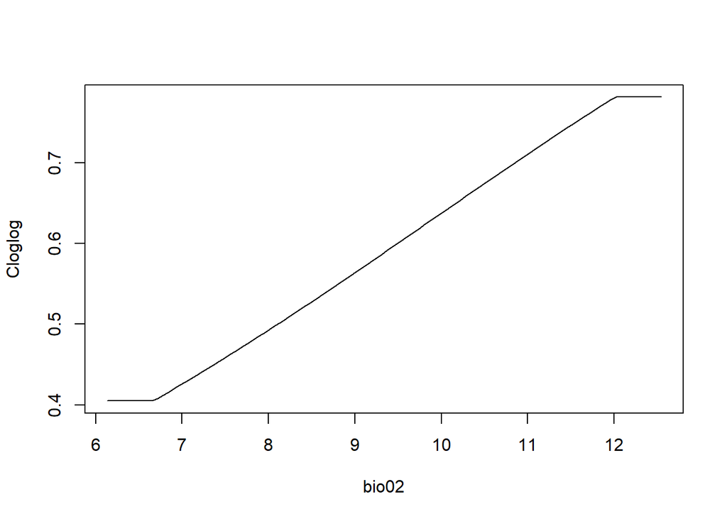

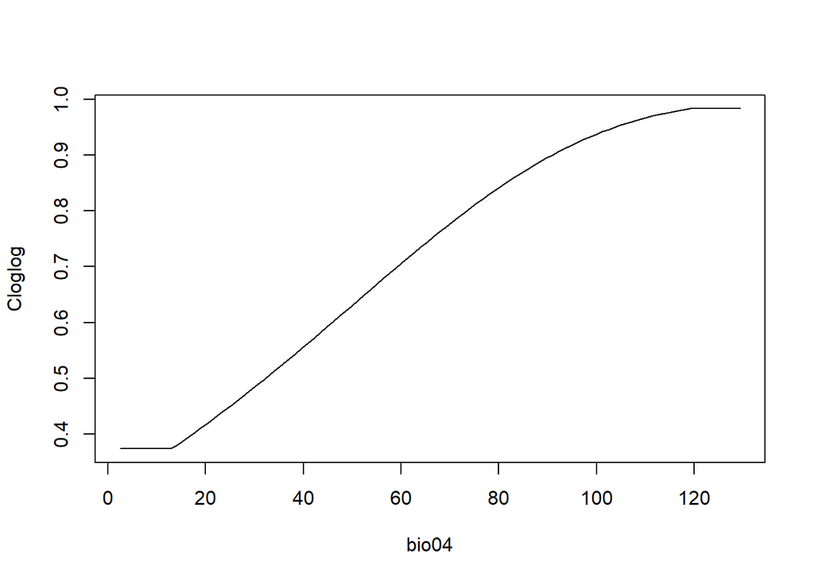

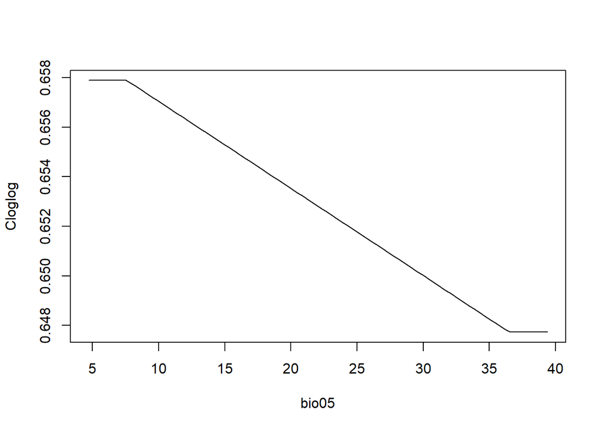

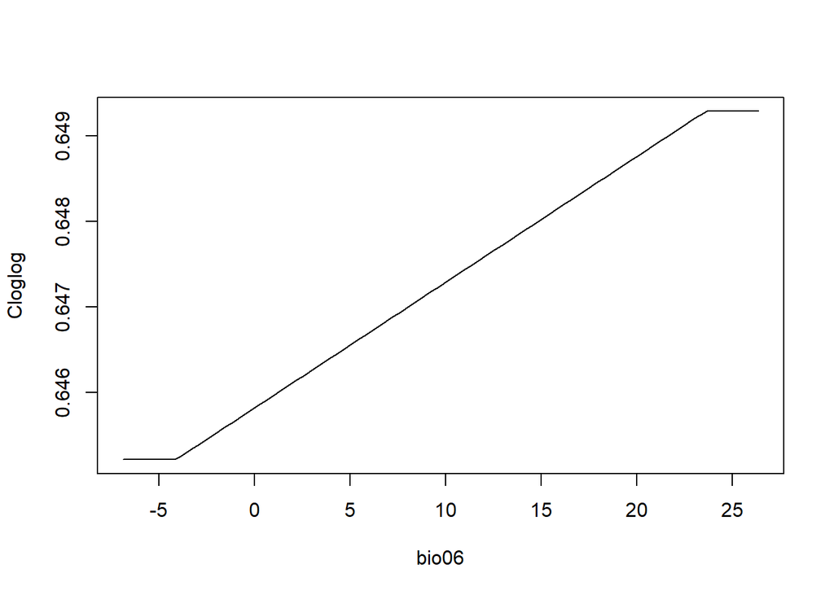

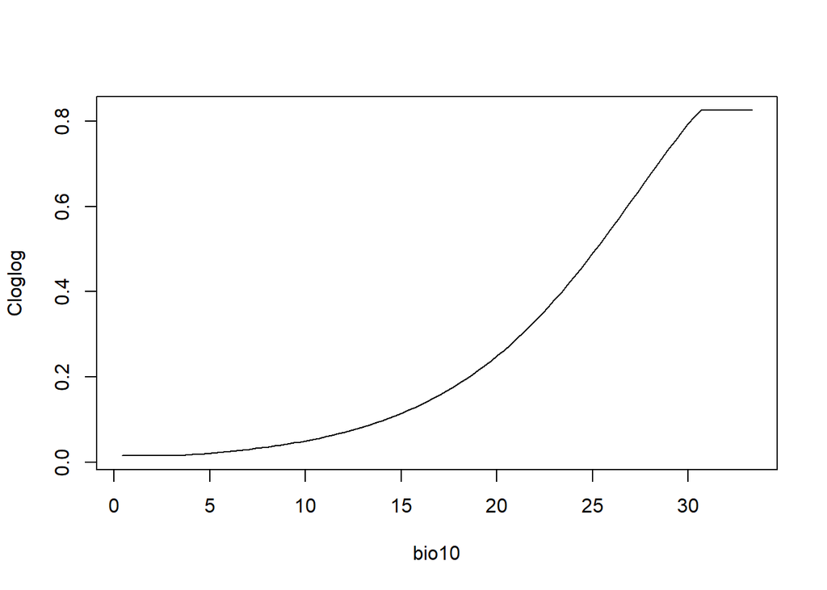

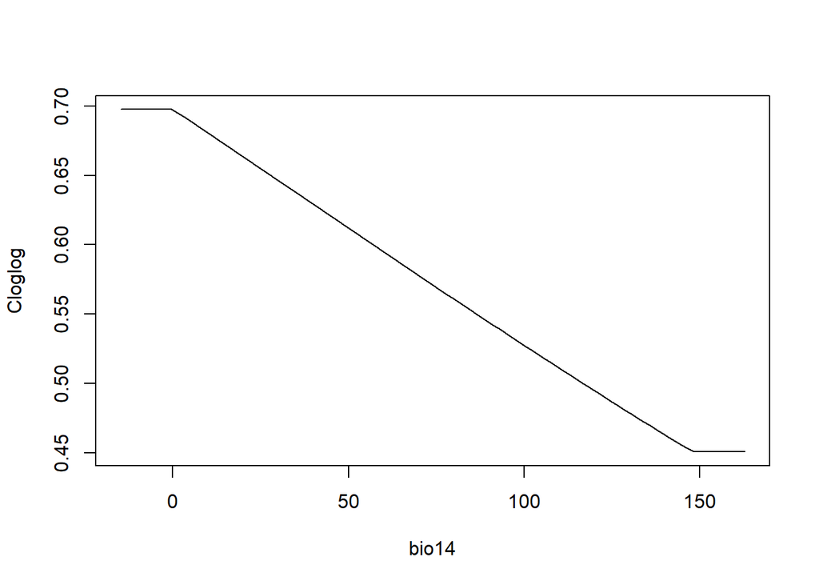

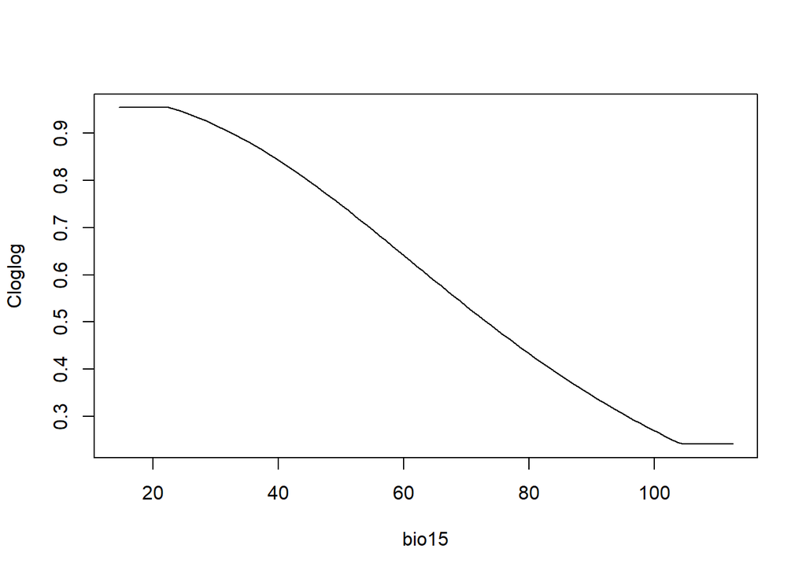

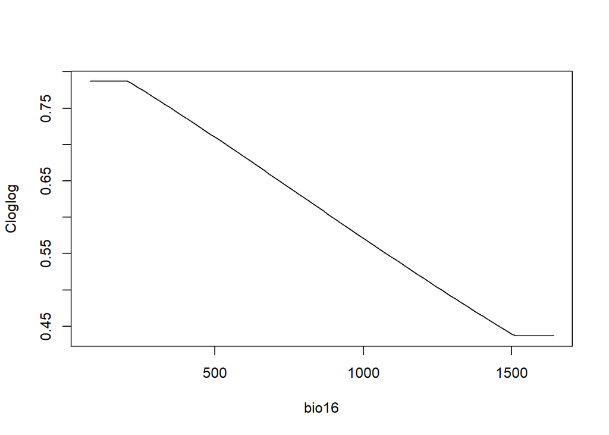

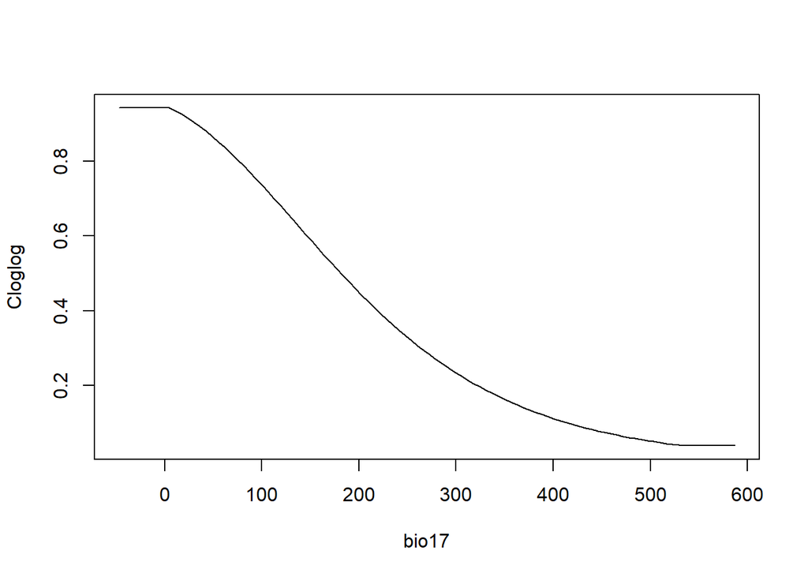

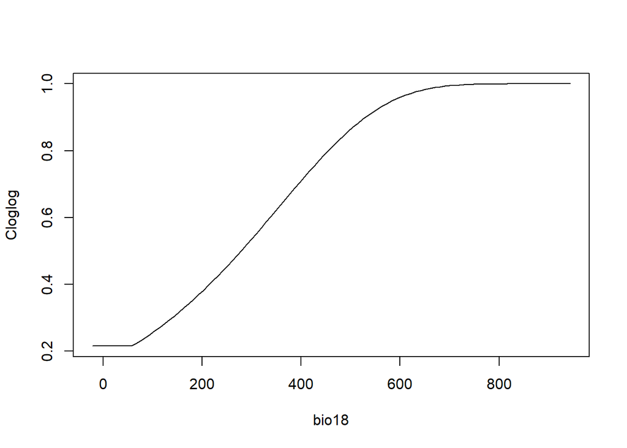

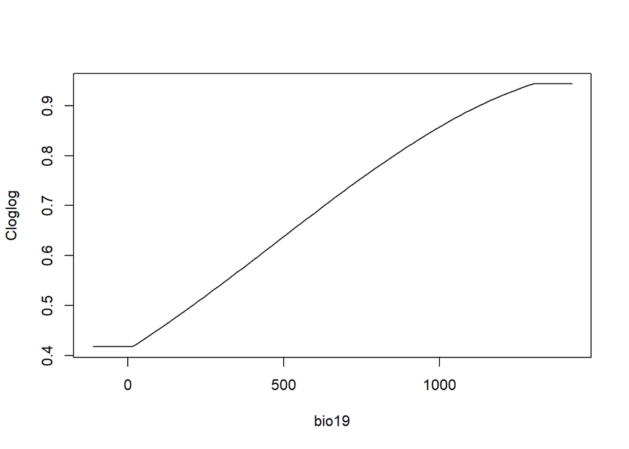

```r
# Retrieve env variables
n <- mxNonzeroCoefs(model_Da@models[["fc.L_rm.2"]], "maxnet")

# Create response curves
for (i in n) {
maxnet::response.plot(
  model_Da@models[["fc.L_rm.2"]],
  v = i,
  type = "cloglog")
}
```